# Reading a Lobbying Disclosure Filing

A quarterly lobbying disclosure, and the two things the form was built not to record

Democracy’s Data

Last updated September 13, 2026 at 10:53a EDT

A law firm filed a form with the Secretary of the Senate on behalf of a small city in Utah, covering the second quarter of 2024. On line 12 of that form, in the box headed *income relating to lobbying activities*, somebody wrote $20,000. That is the whole of what the federal government knows about how much Millcreek, Utah, spent influencing Congress in those three months. Not a range, not an invoice, not a rate: one figure, rounded to the nearest ten thousand dollars because the form says to.[^1]

Two pages later the same form names the subjects the money was spent on. There are two of them, on separate sheets, and the form asks for no division of the money between them.

Now scale that up. The question everybody puts to the lobbying register is **how much was spent lobbying on a given issue** — health care, defence, immigration. It is the right question to ask. Lobbying is money spent on what officeholders do after the election, and the corporations and trade associations that do most of it spend more on it each year than it costs to run Congress.[^2] Legislators have finite attention, and whoever gets it shapes what gets considered. So: can the register answer it?

## The test

Every number here comes from the Senate’s Lobbying Disclosure Act database, where the Secretary of the Senate publishes every registration and quarterly report as filed, searchable at https://lda.senate.gov/system/public/; the Clerk of the House publishes the same filings at https://disclosurespreview.house.gov/. That is 1,500 filings from the second quarter of 2024, and the 773 individual lobbyists named on them, out of 19,016 filings the quarter received.

This is the record to ask, because it is the only one where the money and the subjects appear on the same document. Since the **Lobbying Disclosure Act of 1995**,[^3] anyone paid to lobby the federal government files a report — twice a year at first, quarterly since 2008 — saying who is paying, roughly how much, what issues, and which parts of government were contacted. Nobody compiled it. Registrants — the lobbying firms and in-house lobbying offices the Act requires to register — typed it, because the law obliges them to. It is also self-reported and unchecked, the same arrangement as the campaign-finance filings this cluster’s chapter on disclosure describes.

The test is to take one filing, read it as the database hands it over and again as the filer saw it, and try to attach a dollar figure to a subject.

## The data

The 1,500 filings are the first the database lists for the quarter, not a random draw:

| Quantity | Value |
| --- | --- |
| Filings in the quarter (Q2 2024) | 19,016 |
| Filings retrieved here | 1,500 |
| Share | 7.9% |
| Why not all of them | The database hands over 25 filings per request |

**That is 7.9% of the quarter, and it is a fact about how the database hands records over rather than about lobbying.** The database is entirely public: no key, no registration, no fee. But it gives out records twenty-five at a time and no faster, so the whole quarter would take 761 requests, and this brief stopped after the first 1,500 filings. The consequence runs through every number below — **rates and rankings are informative here, totals are not.** No total dollar figure appears anywhere in this brief, because its denominator, the bottom number a rate is divided by, would be an accident of how many requests somebody was willing to make.

What the database hands over is not a table. Each filing is a record with lists inside it: a list of issue areas, and under each of them a list of the lobbyists who worked on it. Here is the Millcreek filing as the Senate’s database publishes it, with the address blocks and the filer’s telephone number left out and the descriptions cut short:

| Field | Value |
| --- | --- |
| filing_uuid | 302fd116-100b-475c-9d3b-37c3c78dcdc5 |
| filing_type | Q2 |
| income | 20000.00 |
| expenses | null |
| client.name | MILLCREEK, UTAH |
| client.state | UT |
| registrant.name | BARKER LEAVITT, PLLC (SKA MR. JAMES C. BARKER) |
| registrant.state | DC |
| lobbying_activities[1].general_issue_code_display | Budget/Appropriations |
| lobbying_activities[1].description | FY24 Appropriations Bill DHS/FEMA. Community Project Funding Request for Neff’s … |
| lobbying_activities[1].lobbyists[1].lobbyist.last_name | LEAVITT |
| lobbying_activities[1].lobbyists[1].covered_position | Legislative Director- Sen. Josh Hawley |
| lobbying_activities[1].lobbyists[2].lobbyist.last_name | BARKER |
| lobbying_activities[1].lobbyists[2].covered_position | null |
| lobbying_activities[2].general_issue_code_display | Disaster Planning/Emergencies |
| lobbying_activities[2].description | Advocacy for a FEMA BRIC Grant for Millcreek, UT … |
| lobbying_activities[2].lobbyists | *…the same two people again…* |

Flattened into `filings.csv`, that whole tree is one row of six columns:

| Client | Registrant | Client state | Amount | Issues | Lobbyists |
| --- | --- | --- | --- | --- | --- |
| MILLCREEK, UTAH | BARKER LEAVITT, PLLC (SKA MR. JAMES C. BARKER) | UT | $20,000 | 2 | 2 |

The `client` is the organization buying influence and the `registrant` is the firm selling it; when the two names match, an organization is lobbying for itself. **A tree became six numbers and strings, and the tree is where the content was.** Four decisions live inside those six columns.

**`n_lobbyists` is 2, and the obvious arithmetic gives 4.** The same two people are listed under both issue areas, because the form asks who lobbied on each issue and the honest answer repeated. Somebody had to decide that a person named twice is one lobbyist, which also means this column cannot tell you how much work was done.

**`n_issues` is a length, not a subject.** The issue *codes* went to `issues.csv` and the descriptions went nowhere, so a filing about appropriations and one about disaster planning are indistinguishable here beyond the count.

**One of two `state` fields was kept.** The client sits in Utah and the registrant in Washington, D.C., and `client_state` is the client’s. That is right for asking who buys influence and wrong for asking where the industry is.

**`amount` arrives as the text `"20000.00"`, not as a number.** Registrations carry `null` there rather than a figure, and they are a different `filing_type` from the quarterly reports, so the type has to be filtered before any dollar sign is believed.

One more table matters. `lobbyists.csv` carries a `name` and a `former_government_position` and no filing key, so a lobbyist cannot be tied to the client paying them.

> **Before you read the next table, write a percentage down.** 1,177 of these filings report a positive dollar figure, running from $5,000 to $1,800,000. If these were accounts — salaries, hours and expenses, added up — almost none would land on a round number. **What share of them are exact multiples of $10,000?** Commit to a figure before you look.

## What it says about democracy

Start with the money column, because the first thing it says is that it is not a ledger.

| Quantity | Value |
| --- | --- |
| Filings retrieved | 1,500 |
| Reporting a dollar figure of $0 | 323 |
| Reporting a positive amount | 1,177 |
| Smallest positive amount | $5,000 |
| Median | $30,000 |
| Largest | $1,800,000 |

**323 of 1,500 filings report zero.** Not missing: zero. And the smallest positive figure is exactly $5,000, which is not a coincidence. It is the statutory reporting threshold, and filers below it report nothing rather than a small number.[^4]

| Quantity | Value |
| --- | --- |
| Positive filings | 1,177 |
| Amounts that are a multiple of $10,000 | 919 (78.1%) |
| Amounts that are a multiple of $5,000 | 1,022 (86.8%) |

**78.1% of amounts are round multiples of ten thousand dollars.** Plot every reported figure and the point stops being a statistic.

A real price distribution is smooth. This one lands on the round numbers a person reaches for when asked to estimate.

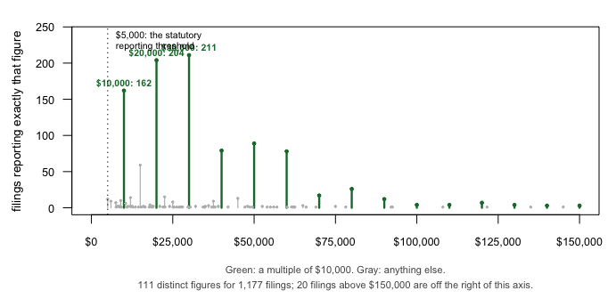

**Figure 1. Every dollar figure reported in the quarter, and how many filings carry it.** One spike per distinct figure is the right form here because the question is about *which* numbers filers reach for, and a histogram would smooth exactly that away by pooling neighbouring values into bins. Green stems are multiples of ten thousand dollars, gray are everything else, and the dashed line is the statutory threshold of $5,000. 111 distinct figures cover all 1,177 paid filings, and the three tallest spikes alone carry 49.0% of them: $30,000, $20,000 and $10,000. 20 filings above $150,000 are off the right of the axis.

**Nothing anybody actually invoiced would look like this.** A real price distribution is smooth, because real work is billed in hours and real hours do not come in units of five thousand dollars. Every figure in this brief carrying a dollar sign is an estimate of that kind, including the median filing — the one in the middle, with as many paid filings above it as below — of $30,000.

**Now the question this brief opened with, and it cannot be answered.** A filing reports one dollar figure and a list of issues, with no division between them. That is easier to see on the form than in any table. Here is the Millcreek filing again, this time as the filer saw it: the LD-2, the quarterly report form the Act prescribes.

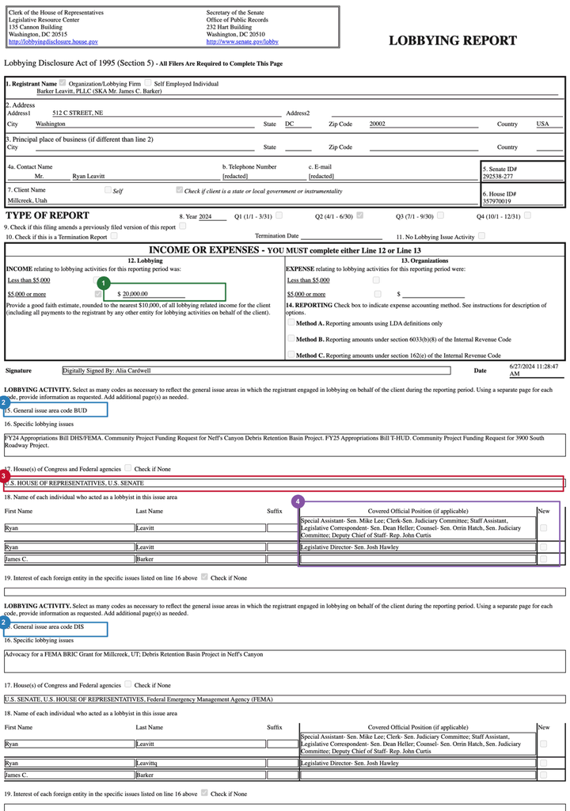

**Figure 2. One filed LD-2, the object every number in this brief is made of.** **1** is line 12, the income box: a single figure, $20,000, for the whole quarter’s work. **2** is line 15, the general issue area code, filled in twice on separate pages, `BUD` and `DIS`. The form asks a page per code and no split of the money, so the box marked 1 belongs to both boxes marked 2 and to neither. **3** is line 17, who was contacted: two institutions, no person and no date; **4** is line 18, where a lobbyist declares a previous government job. The filer’s telephone number and e-mail have been blacked out, and nothing else altered.

| Quantity | Value |
| --- | --- |
| Positive filings covering more than one issue area | 558 |
| Share of positive filings | 47.4% |
| Most issue areas on a single filing | 17 |
| That filing’s client | TECHNOLOGY NETWORK AKA TECHNET |
| That filing’s reported amount | $770,000 |
| Dollars attributable to any one of those issues | unknown |

**47.4% of paid filings cover more than one issue area.** One of them reports $770,000 spread across 17 of them, and the form does not ask how it divided. So any published figure for “lobbying spending on issue X” was produced by somebody making an assumption, usually splitting evenly or assigning the whole amount to every issue it touches. **Neither is in the data.** This is not a cleaning problem that a better extract would fix. It is what Congress wrote on the form.

Since the money cannot be attributed, count mentions instead. That much the register does well.

| Issue area | Times mentioned |
| --- | --- |
| Budget/Appropriations | 395 |
| Health Issues | 271 |
| Defense | 184 |
| Transportation | 154 |
| Taxation/Internal Revenue Code | 116 |
| Medicare/Medicaid | 112 |
| Energy/Nuclear | 111 |
| Education | 109 |
| Trade (domestic/foreign) | 72 |
| Agriculture | 69 |

**Budget/Appropriations leads**, and it is not close. This is not about ideology but about where money is decided: the appropriations process moves more dollars than anything else Congress does. The other question the form asks is which parts of government were contacted.

| Government entity contacted | Times mentioned |
| --- | --- |
| HOUSE OF REPRESENTATIVES | 2511 |
| SENATE | 2492 |
| Health & Human Services, Dept of (HHS) | 145 |
| White House Office | 141 |
| Agriculture, Dept of (USDA) | 118 |
| Energy, Dept of | 108 |
| Transportation, Dept of (DOT) | 100 |
| Centers For Medicare and Medicaid Services (CMS) | 93 |

**The House and Senate dwarf everything**, at 2,511 and 2,492 mentions against 145 for the third-place agency. But read what that field is. **It names an institution, not a person and not a date.** A filing saying “SENATE” has told you that somebody in a hundred-member body was contacted at some point in three months.

One field on the form is far more specific than any of that, and it is the most remarkable thing in the regime. The Act requires a lobbyist to disclose whether they previously held a government position, and to name it.[^5]

| Quantity | Value |
| --- | --- |
| Individual lobbyists named | 773 |
| Disclosing a former government post | 216 |
| Share | 27.9% |

**216 of 773 lobbyists disclose a previous government post, or 27.9%.** More than one in four. A requirement like that could be satisfied with “federal service.” It is not.

| Disclosed former position |
| --- |
| Legislative Director, Sen. John Cornyn; Chief of Staff, Rep. Robert Hurt; Chief of Staff, Rep. Jack Kingston; Chief of Staff, Rep. Virgil Goode |
| Sen. Josh Hawley - Legislative Director |
| Assistant Secretary, HUD |
| 2016-2017: Senate Finance Committee (Detailee) |
| Staff Assistant, LD Rep. Darlene Hooley 1997; 2002-2006; Staff Assistant, LA Rep. Tony Hall 1998-2001; LA Rep. Rush Holt 2001-2002 |

*(Selected from the 216 entries to show the range, not sampled.)*

**They name the member**, and sometimes four of them in sequence with dates. This is a federal database in which lobbyists write down, by statute and unprompted, the names of the legislators whose offices they used to work in. What that connection is worth has been measured elsewhere. Blanes i Vidal, Draca and Fons-Rosen (2012) tracked lobbyists whose former employer left the Senate, and found their revenue fell by about 24% when their senator departed.[^6]

Then the field turns out to be free text with no controlled vocabulary.

| Also found in the same field |
| --- |
| Sr. Vice President |
| President and CEO |
| Consultant |
| Associate Vice President for Public Policy |
| Senior Director, Government Affairs |

**None of those is a government position.** They are private-sector job titles, filed into a field asking about public service. So the 27.9% above is the share who wrote *something* in the box, and separating the real ones would mean reading 216 strings and judging them one at a time. **A field precise enough to name a senator is also loose enough to be unusable in aggregate.**

**The same statute produced one field too coarse to attribute and one too specific to count.** Both were drafted at the same time, by the same Congress, under lobbying from the people who would have to file them.

## What this brief cannot tell you

**It cannot give you a total for anything.** The 7.9% of the quarter here was not drawn at random, so only the rates and rankings are safe to carry away.

**It cannot see anything that never registers.** The Act reaches a person who makes more than one lobbying contact with covered officials — members of Congress, their staff, and senior officials of the executive branch — and spends at least a fifth of their working time for that client on it.[^7] Registration is self-triggered, and campaigns urging constituents to call their representative fall outside entirely.

**It cannot tell you whether lobbying works.** Baumgartner and colleagues (2009) followed 98 policy issues and found that resources predicted outcomes far more weakly than expected.[^8] Nothing in this register settles that argument.

**And this is one quarter**, which supports no trend.

## What you should have learned

- The federal lobbying register reports what was paid and what it was about, and never joins the two: 47.4% of paid filings cover more than one issue area with one undivided dollar figure.
- Any published figure for spending on a policy area therefore rests on somebody’s assumption, not on a column. The largest multi-issue filing here spreads $770,000 across 17 subjects with no split recorded.
- The dollar figures are estimates rather than accounts. 78.1% are exact multiples of ten thousand dollars, and the smallest positive figure in the file is the statutory threshold of $5,000.
- The register is excellent at the thing nobody asks it for: 27.9% of the 773 lobbyists named here disclose a former government post, often naming the member of Congress they worked for.
- A field can be too precise to aggregate. That covered-position box is free text with no vocabulary, so private-sector job titles sit in it beside senators’ names.

## Extensions

None of these is answered above, and every one can be answered from the tables the Sources section hands over.

- `filings.csv` reports an `amount` of zero on many rows. Look at those rows and their `n_issues`. Is zero a real number here, or a way of not answering?
- `filings.csv` also has `client_state`. Group by it. Which states buy the most federal lobbying, and does the ranking look like population, or like something else?
- `lobbyists.csv` has a `former_government_position` column, empty for most rows. Read the filled ones and sort them into genuine public posts and everything else. What share of the 27.9% survives?
- `issues.csv` and `entities.csv` rank what gets lobbied on and who gets lobbied, by `mentions`. Does either ranking look like what the news says lobbying is about?

Two stretch ideas point past the spreadsheet. `quarter.csv` records how many filings existed against how many were taken; say which of your answers above would change if you had all 19,016. And take one client, find its next quarter’s filing on the Senate’s site, and see whether the figure moved or simply repeated.

## Sources

**Data**

- United States Senate, Office of Public Records, Lobbying Disclosure Act database, second-quarter 2024 reports. Searchable at https://lda.senate.gov/system/public/; the same records are served in bulk at https://lda.senate.gov/api/. The Clerk of the House publishes the same filings at https://disclosurespreview.house.gov/.
- Lobbying Disclosure Act of 1995, as amended, 2 U.S.C. §1601 et seq. https://www.law.cornell.edu/uscode/text/2/1601
- The filed LD-2 in Figure 2 is the public print view of filing `302fd116-100b-475c-9d3b-37c3c78dcdc5` (Barker Leavitt, PLLC for Millcreek, Utah, Q2 2024), retrieved 10 August 2026 from https://lda.gov/filings/public/filing/302fd116-100b-475c-9d3b-37c3c78dcdc5/print/. The filer’s telephone number and e-mail were redacted before it was photographed, and four annotations added. Nothing else on the image was altered.

**Academic literature**

- Blanes i Vidal, J., Draca, M. and Fons-Rosen, C. (2012). “Revolving Door Lobbyists.” *American Economic Review* 102(7): 3731–3748. https://www.aeaweb.org/articles?id=10.1257/aer.102.7.3731
- Baumgartner, F. R., Berry, J. M., Hojnacki, M., Kimball, D. C. and Leech, B. L. (2009). *Lobbying and Policy Change: Who Wins, Who Loses, and Why.* University of Chicago Press. https://press.uchicago.edu/ucp/books/book/chicago/L/bo6683614.html
- Drutman, L. (2015). *The Business of America Is Lobbying: How Corporations Became Politicized and Politics Became More Corporate.* Oxford University Press. Summarised by the author in *The Atlantic*, 20 April 2015. https://www.theatlantic.com/business/archive/2015/04/how-corporate-lobbyists-conquered-american-democracy/390822/

**The data itself**

Every figure above is drawn from these tables. They are plain CSV, they open in a spreadsheet, and they are yours to take further.

`entities.csv`, `filings.csv`, `issues.csv`, `lobbyists.csv`, `quarter.csv`

Rebuild this data yourself, with an AI assistant

```
I want to rebuild a public dataset from its original source, without any
starting files. Please do the following and show your work.

THE SOURCE. The Lobbying Disclosure Act database, run by the Senate
and the Clerk of the House. Every lobbying firm files a quarterly
report naming its client, its lobbyists, the issues worked and the
money. The filings API is free, no account or key:
https://lda.gov/api/v1/filings/?filing_year=2024&filing_period=second_quarter&filing_type=Q2
(The older address, lda.senate.gov, now redirects there.) Each record
is one quarterly filing; the second quarter of 2024 held about
nineteen thousand of them.

HOW TO DOWNLOAD IT. Two things to know. First, the filter: leave filing_type=Q2
off and the API still answers, cheerfully, with registration records
whose money fields are null — a table of the right shape and almost
entirely zeros, and nothing warns you. Second, the pace: an anonymous
caller gets 25 records per request and about fifteen requests a
minute, so collecting sixty pages takes several patient minutes, and
the whole quarter would take hours nobody owes you.

WHAT TO BUILD.
1. From the first sixty pages, a table of 1,500 filings: client,
   registrant, client state, the dollar amount (a firm reports income,
   an organisation lobbying for itself reports expenses — fold the two
   together), how many issue areas, and how many distinct lobbyists.
2. A list of the distinct lobbyists named, keeping people apart by the
   database's own id rather than by name — namesakes are real people,
   not duplicates.
3. The denominator: the total count of these filings the API reports
   for the quarter, so the sample's size is stated against it.

CHECK YOUR WORK. The copy this book used was downloaded in August 2026.
If your rebuild matches it, you should find:
- 1,500 filings collected — 7.9% of the 19,016 the quarter held that
  day
- 773 distinct lobbyists across them
- without filing_type=Q2, the same query claimed 23,989 records
The quarter's count is live — filings are amended for years — and the
API's default ordering decides which 1,500 you get, so expect the
sample to move. Drift here is the database breathing, not an error.
```

[^1]: 2 U.S.C. §1604(c): estimates above $5,000 are rounded to the nearest $10,000: https://www.law.cornell.edu/uscode/text/2/1604.
[^2]: Lee Drutman, *The Business of America Is Lobbying* (New York: Oxford University Press, 2015). His summary of the book’s figures — about $2.6 billion a year of reported corporate lobbying against about $2 billion to fund the House and Senate, and $34 of corporate lobbying for every dollar spent by unions and public-interest groups together — is “How Corporate Lobbyists Conquered American Democracy,” *The Atlantic*, 20 April 2015: https://www.theatlantic.com/business/archive/2015/04/how-corporate-lobbyists-conquered-american-democracy/390822/.
[^3]: 2 U.S.C. §1601 and following: https://www.law.cornell.edu/uscode/text/2/1601. Reports were twice-yearly until the Honest Leadership and Open Government Act of 2007 made them quarterly: https://www.govinfo.gov/app/details/PLAW-110publ81.
[^4]: 2 U.S.C. §1604(b)(3) and (c): a firm reports a good-faith estimate of its income from the client, or, where that income did not exceed $5,000, “a statement that income or expenses totaled less than $5,000 for the reporting period”: https://www.law.cornell.edu/uscode/text/2/1604.
[^5]: 2 U.S.C. §1603(b)(6): any covered executive- or legislative-branch position held in the twenty years before the lobbyist first acted for the client: https://www.law.cornell.edu/uscode/text/2/1603.
[^6]: Jordi Blanes i Vidal, Mirko Draca and Christian Fons-Rosen, “Revolving Door Lobbyists,” *American Economic Review* 102, no. 7 (2012): 3731–3748, https://www.aeaweb.org/articles?id=10.1257/aer.102.7.3731.
[^7]: The definition of “lobbyist” at 2 U.S.C. §1602(10): https://www.law.cornell.edu/uscode/text/2/1602.
[^8]: Frank R. Baumgartner, Jeffrey M. Berry, Marie Hojnacki, David C. Kimball and Beth L. Leech, *Lobbying and Policy Change: Who Wins, Who Loses, and Why* (Chicago: University of Chicago Press, 2009), https://press.uchicago.edu/ucp/books/book/chicago/L/bo6683614.html.